# R Notebook

Read the data and unite them in one dataset

```r
train_data <- data.table::fread('train.csv') #21,263 rows, 82 cols
unique_m_data <- data.table::fread('unique_m.csv')  %>% #21,263 rows, 88 cols
  dplyr::select(-critical_temp) #21,263 rows, 87 cols
super_conductors_df <- cbind (train_data, unique_m_data) %>%
  dplyr::select(-material) #21,263 rows, 168 cols
```

We want to predict critical_temp using all the other variables (or some of them).

Now we will split the data in two halfs to get train data and test data. Also, we will delete the columns that don’t have any information (elements not present in any of the compiunds).

```r
super_conductors_df %<>% dplyr::mutate(id = row_number()) %>%
  dplyr::select(where(is.numeric)) %>%
  dplyr::select(where(~max(.) != 0))  #160 cols
train <- super_conductors_df %>% dplyr::slice_sample(prop = 0.5)
test  <- dplyr::anti_join(super_conductors_df, train, by = 'id') # idea about how to do this and about anti-join from https://stackoverflow.com/questions/17200114/how-to-split-data-into-training-testing-sets-using-sample-function
```

We will standardize the train data and the test data according to the train data (all but the critical_temp column).

```r
# caret function taken from https://stackoverflow.com/questions/51685341/r-how-to-normalize-one-dataframe-test-set-given-the-values-of-a-different-dat
train_stats <- caret::preProcess(train %>% dplyr::select(-critical_temp), method = "scale")
train_n <- predict(train_stats, train %>% dplyr::select(-critical_temp)) %>% cbind(.,  train %>% dplyr::select(critical_temp))
train_n %>% pastecs::stat.desc()
```

|  | number_of_elements | mean_atomic_mass | wtd_mean_atomic_mass | gmean_atomic_mass | wtd_gmean_atomic_mass | entropy_atomic_mass | wtd_entropy_atomic_mass | range_atomic_mass | wtd_range_atomic_mass | std_atomic_mass | wtd_std_atomic_mass | mean_fie | wtd_mean_fie | gmean_fie | wtd_gmean_fie | entropy_fie | wtd_entropy_fie | range_fie | wtd_range_fie | std_fie | wtd_std_fie | mean_atomic_radius | wtd_mean_atomic_radius | gmean_atomic_radius | wtd_gmean_atomic_radius | entropy_atomic_radius | wtd_entropy_atomic_radius | range_atomic_radius | wtd_range_atomic_radius | … |
| --- | --- | --- | --- | --- | --- | --- | --- | --- | --- | --- | --- | --- | --- | --- | --- | --- | --- | --- | --- | --- | --- | --- | --- | --- | --- | --- | --- | --- | --- | --- |
| nbr.val | 1.063100e+04 | 1.063100e+04 | 1.063100e+04 | 1.063100e+04 | 1.063100e+04 | 1.063100e+04 | 1.063100e+04 | 1.063100e+04 | 1.063100e+04 | 1.063100e+04 | 1.063100e+04 | 1.063100e+04 | 1.063100e+04 | 1.063100e+04 | 1.063100e+04 | 1.063100e+04 | 1.063100e+04 | 1.063100e+04 | 1.063100e+04 | 1.063100e+04 | 1.063100e+04 | 1.063100e+04 | 1.063100e+04 | 1.063100e+04 | 1.063100e+04 | 1.063100e+04 | 1.063100e+04 | 1.063100e+04 | 1.063100e+04 | … |
| nbr.null | 0.000000e+00 | 0.000000e+00 | 0.000000e+00 | 0.000000e+00 | 0.000000e+00 | 1.360000e+02 | 1.360000e+02 | 1.360000e+02 | 1.360000e+02 | 1.360000e+02 | 1.360000e+02 | 0.000000e+00 | 0.000000e+00 | 0.000000e+00 | 0.000000e+00 | 1.360000e+02 | 1.360000e+02 | 1.380000e+02 | 1.360000e+02 | 1.380000e+02 | 1.380000e+02 | 0.000000e+00 | 0.000000e+00 | 0.000000e+00 | 0.000000e+00 | 1.360000e+02 | 1.360000e+02 | 1.460000e+02 | 1.360000e+02 | … |
| nbr.na | 0.000000e+00 | 0.000000e+00 | 0.000000e+00 | 0.000000e+00 | 0.000000e+00 | 0.000000e+00 | 0.000000e+00 | 0.000000e+00 | 0.000000e+00 | 0.000000e+00 | 0.000000e+00 | 0.000000e+00 | 0.000000e+00 | 0.000000e+00 | 0.000000e+00 | 0.000000e+00 | 0.000000e+00 | 0.000000e+00 | 0.000000e+00 | 0.000000e+00 | 0.000000e+00 | 0.000000e+00 | 0.000000e+00 | 0.000000e+00 | 0.000000e+00 | 0.000000e+00 | 0.000000e+00 | 0.000000e+00 | 0.000000e+00 | … |
| min | 6.938300e-01 | 2.351848e-01 | 1.917222e-01 | 1.716567e-01 | 5.341679e-02 | 0.000000e+00 | 0.000000e+00 | 0.000000e+00 | 0.000000e+00 | 0.000000e+00 | 0.000000e+00 | 4.384254e+00 | 2.624168e+00 | 4.900093e+00 | 3.144257e+00 | 0.000000e+00 | 0.000000e+00 | 0.000000e+00 | 0.000000e+00 | 0.000000e+00 | 0.000000e+00 | 3.364807e+00 | 2.241690e+00 | 2.955705e+00 | 1.707735e+00 | 0.000000e+00 | 0.000000e+00 | 0.000000e+00 | 0.000000e+00 | … |
| max | 6.244470e+00 | 7.080971e+00 | 6.237484e+00 | 6.742296e+00 | 5.692973e+00 | 5.423783e+00 | 4.840985e+00 | 3.808780e+00 | 7.617445e+00 | 5.032723e+00 | 5.062828e+00 | 1.495988e+01 | 9.420650e+00 | 1.599740e+01 | 1.111663e+01 | 5.650327e+00 | 6.065981e+00 | 4.225054e+00 | 5.593372e+00 | 4.556800e+00 | 3.736025e+00 | 1.496586e+01 | 1.034092e+01 | 1.359298e+01 | 8.295455e+00 | 5.702957e+00 | 4.642973e+00 | 3.800775e+00 | 5.865540e+00 | … |
| range | 5.550640e+00 | 6.845786e+00 | 6.045761e+00 | 6.570639e+00 | 5.639557e+00 | 5.423783e+00 | 4.840985e+00 | 3.808780e+00 | 7.617445e+00 | 5.032723e+00 | 5.062828e+00 | 1.057563e+01 | 6.796483e+00 | 1.109731e+01 | 7.972374e+00 | 5.650327e+00 | 6.065981e+00 | 4.225054e+00 | 5.593372e+00 | 4.556800e+00 | 3.736025e+00 | 1.160105e+01 | 8.099234e+00 | 1.063728e+01 | 6.587720e+00 | 5.702957e+00 | 4.642973e+00 | 3.800775e+00 | 5.865540e+00 | … |
| sum | 3.037935e+04 | 3.161364e+04 | 2.323945e+04 | 2.452827e+04 | 1.704578e+04 | 3.392164e+04 | 2.820477e+04 | 2.248612e+04 | 1.310880e+04 | 2.349976e+04 | 2.204070e+04 | 9.536840e+04 | 6.462168e+04 | 1.021371e+05 | 7.407615e+04 | 3.618770e+04 | 2.957029e+04 | 1.968557e+04 | 2.297351e+04 | 2.088088e+04 | 1.862044e+04 | 8.459192e+04 | 4.978585e+04 | 7.025424e+04 | 3.587102e+04 | 3.591094e+04 | 2.964934e+04 | 2.203284e+04 | 1.567094e+04 | … |
| median | 2.775320e+00 | 2.879294e+00 | 1.808503e+00 | 2.141012e+00 | 1.087581e+00 | 3.279594e+00 | 2.864196e+00 | 2.250886e+00 | 9.777375e-01 | 2.247350e+00 | 2.218470e+00 | 8.900054e+00 | 6.216168e+00 | 9.498038e+00 | 7.169432e+00 | 3.561399e+00 | 2.748309e+00 | 2.474790e+00 | 2.271320e+00 | 2.430808e+00 | 2.018238e+00 | 8.052100e+00 | 4.376624e+00 | 6.520643e+00 | 3.152891e+00 | 3.552584e+00 | 3.064837e+00 | 2.538799e+00 | 1.234064e+00 | … |
| mean | 2.857619e+00 | 2.973723e+00 | 2.186008e+00 | 2.307240e+00 | 1.603404e+00 | 3.190823e+00 | 2.653068e+00 | 2.115147e+00 | 1.233073e+00 | 2.210494e+00 | 2.073248e+00 | 8.970784e+00 | 6.078608e+00 | 9.607482e+00 | 6.967938e+00 | 3.403979e+00 | 2.781515e+00 | 1.851714e+00 | 2.160992e+00 | 1.964150e+00 | 1.751523e+00 | 7.957099e+00 | 4.683082e+00 | 6.608432e+00 | 3.374190e+00 | 3.377946e+00 | 2.788952e+00 | 2.072509e+00 | 1.474079e+00 | … |
| SE.mean | 9.698687e-03 | 9.698687e-03 | 9.698687e-03 | 9.698687e-03 | 9.698687e-03 | 9.698687e-03 | 9.698687e-03 | 9.698687e-03 | 9.698687e-03 | 9.698687e-03 | 9.698687e-03 | 9.698687e-03 | 9.698687e-03 | 9.698687e-03 | 9.698687e-03 | 9.698687e-03 | 9.698687e-03 | 9.698687e-03 | 9.698687e-03 | 9.698687e-03 | 9.698687e-03 | 9.698687e-03 | 9.698687e-03 | 9.698687e-03 | 9.698687e-03 | 9.698687e-03 | 9.698687e-03 | 9.698687e-03 | 9.698687e-03 | … |

[output cut: 4 more lines]

```r
test_n <- predict (train_stats, test%>% dplyr::select(-critical_temp))%>% cbind(.,  test %>% dplyr::select(critical_temp))
test_n %>% pastecs::stat.desc() # some minimal values are less than zero
```

|  | number_of_elements | mean_atomic_mass | wtd_mean_atomic_mass | gmean_atomic_mass | wtd_gmean_atomic_mass | entropy_atomic_mass | wtd_entropy_atomic_mass | range_atomic_mass | wtd_range_atomic_mass | std_atomic_mass | wtd_std_atomic_mass | mean_fie | wtd_mean_fie | gmean_fie | wtd_gmean_fie | entropy_fie | wtd_entropy_fie | range_fie | wtd_range_fie | std_fie | wtd_std_fie | mean_atomic_radius | wtd_mean_atomic_radius | gmean_atomic_radius | wtd_gmean_atomic_radius | entropy_atomic_radius | wtd_entropy_atomic_radius | range_atomic_radius | wtd_range_atomic_radius | … |
| --- | --- | --- | --- | --- | --- | --- | --- | --- | --- | --- | --- | --- | --- | --- | --- | --- | --- | --- | --- | --- | --- | --- | --- | --- | --- | --- | --- | --- | --- | --- |
| nbr.val | 1.063200e+04 | 1.063200e+04 | 1.063200e+04 | 1.063200e+04 | 1.063200e+04 | 1.063200e+04 | 1.063200e+04 | 1.063200e+04 | 1.063200e+04 | 1.063200e+04 | 1.063200e+04 | 1.063200e+04 | 1.063200e+04 | 1.063200e+04 | 1.063200e+04 | 1.063200e+04 | 1.063200e+04 | 1.063200e+04 | 1.063200e+04 | 1.063200e+04 | 1.063200e+04 | 1.063200e+04 | 1.063200e+04 | 1.063200e+04 | 1.063200e+04 | 1.063200e+04 | 1.063200e+04 | 1.063200e+04 | 1.063200e+04 | … |
| nbr.null | 0.000000e+00 | 0.000000e+00 | 0.000000e+00 | 0.000000e+00 | 0.000000e+00 | 1.490000e+02 | 1.490000e+02 | 1.490000e+02 | 1.490000e+02 | 1.490000e+02 | 1.490000e+02 | 0.000000e+00 | 0.000000e+00 | 0.000000e+00 | 0.000000e+00 | 1.490000e+02 | 1.490000e+02 | 1.510000e+02 | 1.490000e+02 | 1.510000e+02 | 1.500000e+02 | 0.000000e+00 | 0.000000e+00 | 0.000000e+00 | 0.000000e+00 | 1.490000e+02 | 1.490000e+02 | 1.590000e+02 | 1.500000e+02 | … |
| nbr.na | 0.000000e+00 | 0.000000e+00 | 0.000000e+00 | 0.000000e+00 | 0.000000e+00 | 0.000000e+00 | 0.000000e+00 | 0.000000e+00 | 0.000000e+00 | 0.000000e+00 | 0.000000e+00 | 0.000000e+00 | 0.000000e+00 | 0.000000e+00 | 0.000000e+00 | 0.000000e+00 | 0.000000e+00 | 0.000000e+00 | 0.000000e+00 | 0.000000e+00 | 0.000000e+00 | 0.000000e+00 | 0.000000e+00 | 0.000000e+00 | 0.000000e+00 | 0.000000e+00 | 0.000000e+00 | 0.000000e+00 | 0.000000e+00 | … |
| min | 6.938300e-01 | 2.351848e-01 | 2.071695e-01 | 1.834152e-01 | 8.700291e-02 | 0.000000e+00 | 0.000000e+00 | 0.000000e+00 | 0.000000e+00 | 0.000000e+00 | 0.000000e+00 | 5.801109e+00 | 3.511702e+00 | 6.402529e+00 | 4.207695e+00 | 0.000000e+00 | 0.000000e+00 | 0.000000e+00 | 0.000000e+00 | 0.000000e+00 | 0.000000e+00 | 2.410608e+00 | 1.665652e+00 | 2.189474e+00 | 1.336181e+00 | 0.000000e+00 | 0.000000e+00 | 0.000000e+00 | 0.000000e+00 | … |
| max | 6.244470e+00 | 7.080971e+00 | 6.237484e+00 | 6.742296e+00 | 5.692973e+00 | 5.423783e+00 | 4.874905e+00 | 3.808780e+00 | 7.513604e+00 | 5.032723e+00 | 5.062828e+00 | 1.533146e+01 | 9.176550e+00 | 1.713532e+01 | 1.099527e+01 | 5.650327e+00 | 6.117830e+00 | 4.225054e+00 | 4.724585e+00 | 4.487355e+00 | 3.746574e+00 | 1.270591e+01 | 8.779375e+00 | 1.154035e+01 | 7.042786e+00 | 5.702957e+00 | 4.687709e+00 | 3.800775e+00 | 6.898935e+00 | … |
| range | 5.550640e+00 | 6.845786e+00 | 6.030314e+00 | 6.558881e+00 | 5.605970e+00 | 5.423783e+00 | 4.874905e+00 | 3.808780e+00 | 7.513604e+00 | 5.032723e+00 | 5.062828e+00 | 9.530352e+00 | 5.664848e+00 | 1.073279e+01 | 6.787576e+00 | 5.650327e+00 | 6.117830e+00 | 4.225054e+00 | 4.724585e+00 | 4.487355e+00 | 3.746574e+00 | 1.029530e+01 | 7.113723e+00 | 9.350878e+00 | 5.706605e+00 | 5.702957e+00 | 4.687709e+00 | 3.800775e+00 | 6.898935e+00 | … |
| sum | 3.033217e+04 | 3.146840e+04 | 2.308195e+04 | 2.437740e+04 | 1.686284e+04 | 3.383971e+04 | 2.811061e+04 | 2.252991e+04 | 1.306700e+04 | 2.352484e+04 | 2.212810e+04 | 9.569770e+04 | 6.472229e+04 | 1.024913e+05 | 7.419531e+04 | 3.614895e+04 | 2.956540e+04 | 1.972182e+04 | 2.296281e+04 | 2.093211e+04 | 1.862913e+04 | 8.411019e+04 | 4.961723e+04 | 6.984534e+04 | 3.574259e+04 | 3.586002e+04 | 2.957376e+04 | 2.195026e+04 | 1.570572e+04 | … |
| median | 2.775320e+00 | 2.874733e+00 | 1.814727e+00 | 2.141548e+00 | 1.087041e+00 | 3.279594e+00 | 2.846123e+00 | 2.250886e+00 | 9.937783e-01 | 2.248018e+00 | 2.220704e+00 | 8.941893e+00 | 6.239153e+00 | 9.510863e+00 | 7.169860e+00 | 3.546790e+00 | 2.754866e+00 | 2.474790e+00 | 2.294780e+00 | 2.428193e+00 | 2.022794e+00 | 8.043730e+00 | 4.363951e+00 | 6.492382e+00 | 3.150326e+00 | 3.538784e+00 | 3.057993e+00 | 2.538799e+00 | 1.238127e+00 | … |
| mean | 2.852913e+00 | 2.959782e+00 | 2.170989e+00 | 2.292833e+00 | 1.586046e+00 | 3.182817e+00 | 2.643963e+00 | 2.119066e+00 | 1.229025e+00 | 2.212645e+00 | 2.081274e+00 | 9.000913e+00 | 6.087499e+00 | 9.639893e+00 | 6.978490e+00 | 3.400014e+00 | 2.780794e+00 | 1.854950e+00 | 2.159783e+00 | 1.968784e+00 | 1.752176e+00 | 7.911041e+00 | 4.666783e+00 | 6.569351e+00 | 3.361794e+00 | 3.372839e+00 | 2.781580e+00 | 2.064547e+00 | 1.477212e+00 | … |
| SE.mean | 9.671962e-03 | 9.805402e-03 | 9.690292e-03 | 9.719971e-03 | 9.667595e-03 | 9.654544e-03 | 9.685585e-03 | 9.706982e-03 | 9.683119e-03 | 9.662751e-03 | 9.727990e-03 | 1.010925e-02 | 9.723584e-03 | 1.012098e-02 | 9.754928e-03 | 9.701155e-03 | 9.745272e-03 | 9.752672e-03 | 9.718814e-03 | 9.753857e-03 | 9.703789e-03 | 9.921534e-03 | 9.687289e-03 | 9.843006e-03 | 9.652126e-03 | 9.689493e-03 | 9.748364e-03 | 9.674776e-03 | 9.813964e-03 | … |

[output cut: 4 more lines]

```r
# that's because we were using train data for standartization
```

Now we will build linear model that uses all the features we have and predicts the critical temperature

```r
model1train <- lm(critical_temp ~ ., data = train_n)
summary(model1train)
```

```
##
## Call:
## lm(formula = critical_temp ~ ., data = train_n)
##
## Residuals:
##      Min       1Q   Median       3Q      Max
## -107.362   -8.137    0.825   10.126   90.313
##
## Coefficients:
##                                   Estimate Std. Error t value Pr(>|t|)
## (Intercept)                     -1.355e+01  8.024e+00  -1.689 0.091268 .
## number_of_elements               2.057e+00  1.502e+00   1.370 0.170775
## mean_atomic_mass                 2.299e+01  3.368e+00   6.828 9.10e-12 ***
## wtd_mean_atomic_mass            -4.274e+01  4.830e+00  -8.849  < 2e-16 ***
## gmean_atomic_mass               -1.138e+01  3.467e+00  -3.283 0.001032 **
## wtd_gmean_atomic_mass            2.991e+01  4.968e+00   6.020 1.81e-09 ***
## entropy_atomic_mass             -9.199e+00  2.529e+00  -3.637 0.000277 ***
## wtd_entropy_atomic_mass          3.298e+00  2.117e+00   1.558 0.119290
## range_atomic_mass                9.128e+00  1.283e+00   7.114 1.20e-12 ***
## wtd_range_atomic_mass            2.752e+00  8.144e-01   3.379 0.000730 ***
## std_atomic_mass                 -8.089e+00  1.767e+00  -4.577 4.78e-06 ***
## wtd_std_atomic_mass              3.467e-01  1.541e+00   0.225 0.821972
## mean_fie                        -1.698e+01  7.961e+00  -2.134 0.032901 *
## wtd_mean_fie                     3.372e+00  1.583e+01   0.213 0.831321
## gmean_fie                        1.330e+01  7.055e+00   1.885 0.059496 .
## wtd_gmean_fie                    2.966e+00  1.308e+01   0.227 0.820598
## entropy_fie                     -9.256e+00  1.156e+01  -0.801 0.423252
## wtd_entropy_fie                  1.848e+01  2.308e+00   8.008 1.29e-15 ***
## range_fie                        9.868e+00  2.899e+00   3.405 0.000665 ***
## wtd_range_fie                    4.025e+00  1.174e+00   3.429 0.000609 ***
## std_fie                         -2.154e+00  3.550e+00  -0.607 0.543931
## wtd_std_fie                     -1.128e+01  3.754e+00  -3.005 0.002658 **
## mean_atomic_radius              -1.074e+01  5.128e+00  -2.094 0.036250 *
## wtd_mean_atomic_radius           6.385e+01  1.003e+01   6.365 2.04e-10 ***
## gmean_atomic_radius              8.234e+00  5.697e+00   1.445 0.148397
## wtd_gmean_atomic_radius         -7.249e+01  1.223e+01  -5.927 3.18e-09 ***
## entropy_atomic_radius           -1.161e+01  1.035e+01  -1.122 0.261993
## wtd_entropy_atomic_radius        6.090e+00  3.156e+00   1.930 0.053688 .
## range_atomic_radius              8.132e+00  2.139e+00   3.801 0.000145 ***
## wtd_range_atomic_radius         -1.481e+00  7.797e-01  -1.900 0.057452 .
```

[output cut: 121 more lines]

```
## Os                               3.364e-01  1.923e-01   1.749 0.080286 .
## Ir                               6.901e-02  2.519e-01   0.274 0.784155
## Pt                               1.535e+00  2.472e-01   6.211 5.45e-10 ***
## Au                              -5.377e-01  2.506e-01  -2.146 0.031880 *
## Hg                               8.862e-01  2.419e-01   3.663 0.000250 ***
## Tl                               1.422e+00  2.032e-01   6.998 2.75e-12 ***
## Pb                               4.055e-01  1.857e-01   2.183 0.029056 *
## Bi                               4.470e+00  3.066e-01  14.579  < 2e-16 ***
## id                              -8.178e-01  2.878e-01  -2.841 0.004503 **
## ---
## Signif. codes:  0 '***' 0.001 '**' 0.01 '*' 0.05 '.' 0.1 ' ' 1
##
## Residual standard error: 16.59 on 10471 degrees of freedom
## Multiple R-squared:  0.7714, Adjusted R-squared:  0.7679
## F-statistic: 222.2 on 159 and 10471 DF,  p-value: < 2.2e-16
```

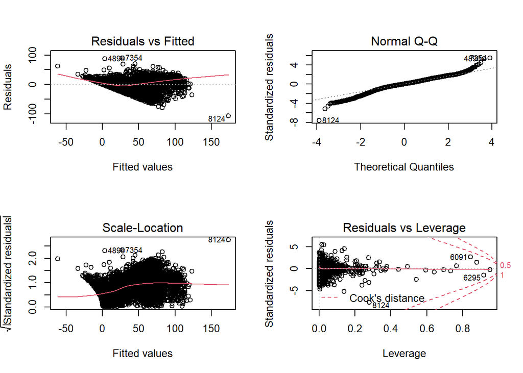

```r
par(mfrow = c(2,2))
plot(model1train)
```

```r
# the next part is taken from https://datascienceplus.com/how-to-apply-linear-regression-in-r/
pred1 <- predict(model1train, newdata = test_n)
rmse <- sqrt(sum(pred1 - test_n$critical_temp)^2)/length(test_n$critical_temp)
c(RMSE = rmse, R2=summary(model1train)$r.squared)
```

```
##      RMSE        R2
## 0.3361145 0.7714172
```

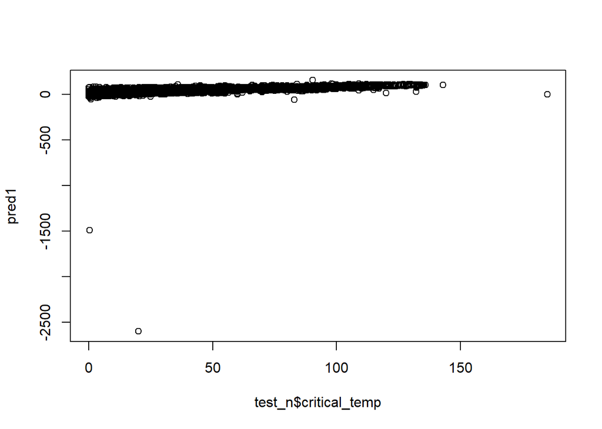

```r
par(mfrow=c(1,1))
plot(test_n$critical_temp, pred1)
```

Adjusted R-squared is >0.75, so the model is not extremely bad. But we can see that some predictors are not significant.

```r
train_pca <- vegan::rda(train_n[, -1], scale = TRUE)
head(summary(train_pca))
```

```
##
## Call:
## rda(X = train_n[, -1], scale = TRUE)
##
## Partitioning of correlations:
##               Inertia Proportion
## Total             159          1
## Unconstrained     159          1
##
## Eigenvalues, and their contribution to the correlations
##
## Importance of components:
##                           PC1    PC2     PC3     PC4    PC5     PC6     PC7
## Eigenvalue            33.2186 9.1750 8.45399 6.76415 5.3583 3.62132 3.39299
## Proportion Explained   0.2089 0.0577 0.05317 0.04254 0.0337 0.02278 0.02134
## Cumulative Proportion  0.2089 0.2666 0.31980 0.36234 0.3960 0.41881 0.44015
##                           PC8     PC9    PC10    PC11    PC12    PC13    PC14
## Eigenvalue            2.90725 2.55616 2.38029 2.22505 2.05477 1.98337 1.84249
## Proportion Explained  0.01828 0.01608 0.01497 0.01399 0.01292 0.01247 0.01159
## Cumulative Proportion 0.45844 0.47451 0.48949 0.50348 0.51640 0.52888 0.54046
##                          PC15    PC16    PC17    PC18     PC19     PC20
## Eigenvalue            1.81708 1.76267 1.65480 1.61471 1.549940 1.510003
## Proportion Explained  0.01143 0.01109 0.01041 0.01016 0.009748 0.009497
## Cumulative Proportion 0.55189 0.56298 0.57339 0.58354 0.593289 0.602786
##                           PC21     PC22     PC23     PC24     PC25     PC26
## Eigenvalue            1.433676 1.422669 1.375204 1.353745 1.311436 1.282580
## Proportion Explained  0.009017 0.008948 0.008649 0.008514 0.008248 0.008067
## Cumulative Proportion 0.611803 0.620751 0.629400 0.637914 0.646162 0.654228
##                           PC27     PC28     PC29     PC30     PC31     PC32
## Eigenvalue            1.249241 1.218621 1.177279 1.165965 1.142823 1.132557
## Proportion Explained  0.007857 0.007664 0.007404 0.007333 0.007188 0.007123
## Cumulative Proportion 0.662085 0.669750 0.677154 0.684487 0.691674 0.698797
##                           PC33     PC34     PC35     PC36     PC37     PC38
## Eigenvalue            1.111085 1.101046 1.080399 1.071742 1.058856 1.045469
## Proportion Explained  0.006988 0.006925 0.006795 0.006741 0.006659 0.006575
## Cumulative Proportion 0.705785 0.712710 0.719505 0.726246 0.732905 0.739480
##                           PC39     PC40     PC41     PC42     PC43     PC44
## Eigenvalue            1.039650 1.037758 1.027845 1.018812 1.013350 1.009985
## Proportion Explained  0.006539 0.006527 0.006464 0.006408 0.006373 0.006352
## Cumulative Proportion 0.746019 0.752546 0.759010 0.765418 0.771791 0.778143
```

[output cut: 102 more lines]

```
## entropy_atomic_mass     -2.3207 0.8335 -0.72566 -0.3915  0.04490  0.68595
## wtd_entropy_atomic_mass -2.5072 0.5421 -0.59629 -0.3018 -0.04509  0.38310
## ....
##
##
## Site scores (weighted sums of species scores)
##
##          PC1      PC2      PC3      PC4      PC5      PC6
## sit1  0.2080 -0.27277  0.04728  0.35206  0.37453  0.36651
## sit2  0.6546  0.25507  0.20131 -0.10349  0.12033  0.05201
## sit3  0.4396 -0.18511  0.12788  0.01105  0.39730 -0.23907
## sit4  0.4964 -0.02643  0.22364 -0.19172 -0.16311 -0.10501
## sit5  0.3767  0.21868  0.06547 -0.33581  0.07477 -0.01572
## sit6 -0.3411  0.03673 -0.11855  0.04119  0.07362  0.07168
## ....
```

```r
vegan::scores(train_pca, display = "species", choices = c(1, 2, 3, 4, 5), scaling = 0)
```

```
##                                           PC1           PC2           PC3
## mean_atomic_mass                 0.0509582531  2.062151e-01 -0.0365610685
## wtd_mean_atomic_mass             0.0979845964  1.783371e-01 -0.0759681194
## gmean_atomic_mass                0.0808062664  2.060108e-01 -0.0054135801
## wtd_gmean_atomic_mass            0.1173324183  1.693705e-01 -0.0488175386
## entropy_atomic_mass             -0.1408125519  9.622976e-02 -0.0872803006
## wtd_entropy_atomic_mass         -0.1521269387  6.259209e-02 -0.0717201655
## range_atomic_mass               -0.1195837171  4.840450e-02 -0.1180595210
## wtd_range_atomic_mass            0.0869365148  9.846378e-02 -0.0559109782
## std_atomic_mass                 -0.0938075847  3.314762e-02 -0.1218340493
## wtd_std_atomic_mass             -0.1074824669  2.459769e-02 -0.1078974331
## mean_fie                        -0.0542612982 -1.765705e-01 -0.0729251537
## wtd_mean_fie                    -0.1266178875 -1.097833e-01  0.0772136228
## gmean_fie                       -0.0208488298 -1.735280e-01 -0.0913752213
## wtd_gmean_fie                   -0.1153318210 -1.263907e-01  0.0723211385
## entropy_fie                     -0.1503235929  5.991264e-02 -0.1137212194
## wtd_entropy_fie                 -0.1032674006  4.213461e-02 -0.2178716581
## range_fie                       -0.1596155767 -3.571954e-02 -0.0074520123
## wtd_range_fie                   -0.0854426460 -3.220706e-02  0.1476697384
## std_fie                         -0.1510811143 -6.637682e-02  0.0102058351
## wtd_std_fie                     -0.1600111627 -2.973101e-02  0.0430088952
## mean_atomic_radius               0.0180588636  2.162138e-01  0.0734107226
## wtd_mean_atomic_radius           0.1166166914  1.628015e-01 -0.0717367766
## gmean_atomic_radius              0.0753010246  2.215774e-01  0.0379062611
## wtd_gmean_atomic_radius          0.1347107463  1.364347e-01 -0.0777872338
## entropy_atomic_radius           -0.1471620422  7.377957e-02 -0.1153726448
## wtd_entropy_atomic_radius       -0.1580712927  4.468953e-02 -0.0958644813
## range_atomic_radius             -0.1595713895 -2.811003e-02  0.0171389898
## wtd_range_atomic_radius          0.0989071142  5.666777e-02 -0.0043213087
## std_atomic_radius               -0.1454447350 -7.864786e-02  0.0285871239
## wtd_std_atomic_radius           -0.1569312618 -4.611245e-02  0.0357598644
## mean_Density                     0.1067585568  1.382996e-01 -0.0783698448
## wtd_mean_Density                 0.1287081849  1.164826e-01 -0.0949760169
## gmean_Density                    0.1470301821  9.440115e-02 -0.0502606411
## wtd_gmean_Density                0.1524133934  8.740810e-02 -0.0598703049
## entropy_Density                 -0.1169688198  1.049244e-01 -0.1038931979
## wtd_entropy_Density             -0.1102157172  8.449339e-02 -0.1693772961
## range_Density                   -0.0721985898  4.738697e-02 -0.1515405770
## wtd_range_Density                0.0909278489  7.374302e-02 -0.0517273847
## std_Density                     -0.0380702205  3.103981e-02 -0.1574094262
```

[output cut: 267 more lines]

```
## Ta                               0.0092166959 -0.0196665157
## W                                0.0379142025 -0.0489185949
## Re                               0.0143966780 -0.0231538311
## Os                               0.0416499113 -0.0395246491
## Ir                               0.0280127862 -0.0771097442
## Pt                               0.0380566671 -0.0366867133
## Au                               0.0323344862 -0.0344284308
## Hg                               0.0007088618 -0.0325527431
## Tl                              -0.0099510620 -0.0164810215
## Pb                               0.0137621909  0.0161821294
## Bi                               0.0210523635  0.0455190555
## id                              -0.0111351100  0.1016500763
## critical_temp                   -0.0413240884 -0.0688449815
## attr(,"const")
## [1] 36.05642
```

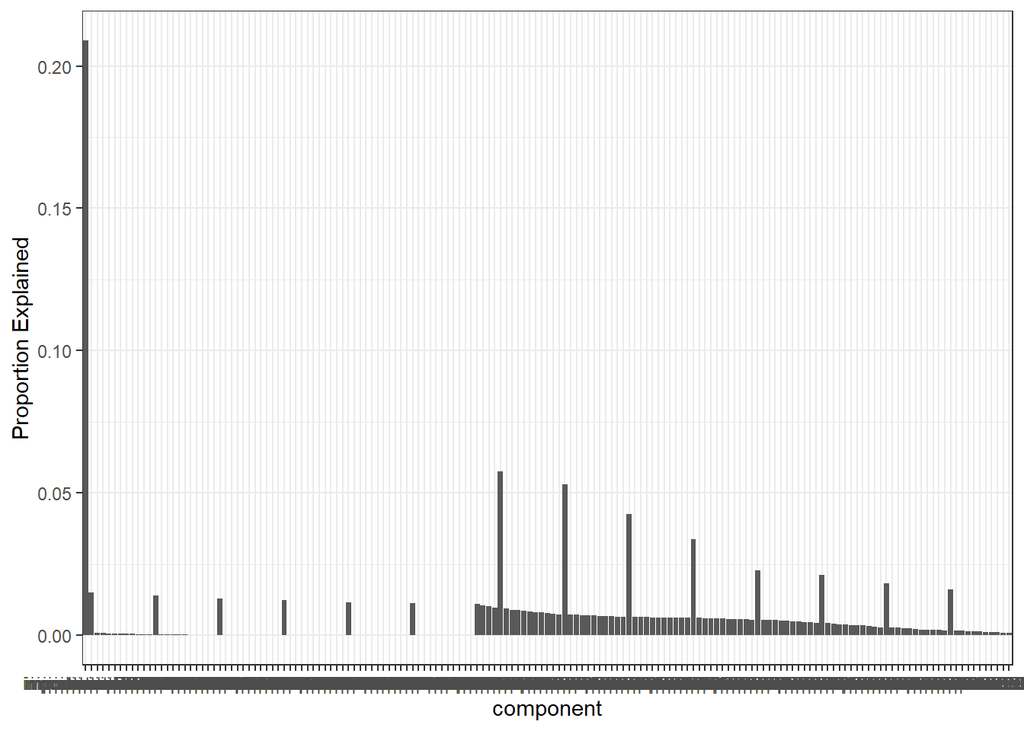

```r
# trying to plot some plots from lecture
pca_summary <- summary(train_pca)
pca_result <- as.data.frame(pca_summary$cont)
plot_data <- as.data.frame(t(pca_result[c("Proportion Explained"),]))
plot_data$component <- rownames(plot_data)

ggplot(plot_data, aes( component, `Proportion Explained`)) + geom_bar(stat = "identity") + theme_bw()
```

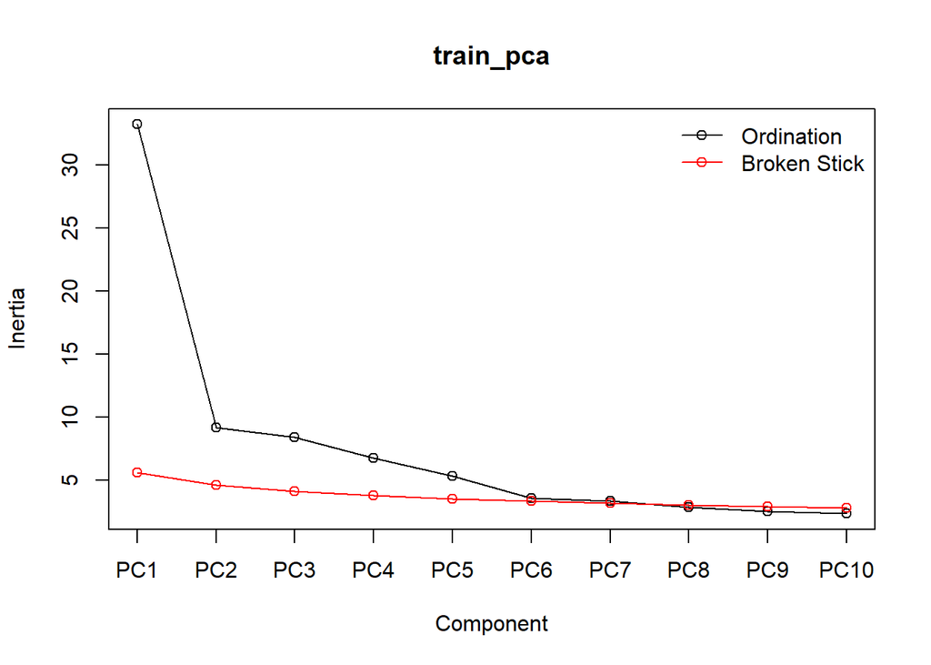

```r
screeplot(train_pca, type = "lines", bstick = TRUE) # I would say first 5 components are the most important
```

Now we can try to apply linear model to the transformed data. I didn’t know how to do it in vegan so tried pcr and prcomp functions.

```r
train_pca_result = prcomp(train_n[, -1])
train_pc_result5 <- train_pca_result$x[,1:5] %>% as.data.frame()%>%cbind(train_n %>% dplyr::select(critical_temp))
test_pc_result5 <- predict(train_pca_result, newdata = test_n[, -1])[,1:5] %>% as.data.frame()%>%cbind(test_n %>% dplyr::select(critical_temp))
```

```r
model2train <- lm(critical_temp ~ ., data = as.data.frame(train_pc_result5))
summary(model2train)
```

```
##
## Call:
## lm(formula = critical_temp ~ ., data = as.data.frame(train_pc_result5))
##
## Residuals:
##      Min       1Q   Median       3Q      Max
## -0.49132 -0.04724  0.00602  0.04944  0.26819
##
## Coefficients:
##               Estimate Std. Error   t value Pr(>|t|)
## (Intercept)  3.478e+01  7.610e-04  45708.61   <2e-16 ***
## PC1         -9.931e-01  2.195e-05 -45247.67   <2e-16 ***
## PC2         -9.933e-02  1.761e-04   -564.01   <2e-16 ***
## PC3         -1.317e-02  2.566e-04    -51.33   <2e-16 ***
## PC4          3.350e-02  2.739e-04    122.33   <2e-16 ***
## PC5          2.186e-02  2.977e-04     73.45   <2e-16 ***
## ---
## Signif. codes:  0 '***' 0.001 '**' 0.01 '*' 0.05 '.' 0.1 ' ' 1
##
## Residual standard error: 0.07846 on 10625 degrees of freedom
## Multiple R-squared:      1,  Adjusted R-squared:      1
## F-statistic: 4.095e+08 on 5 and 10625 DF,  p-value: < 2.2e-16
```

```r
model2test <- lm(critical_temp ~ ., data = as.data.frame(test_pc_result5))
summary(model2test)
```

```
##
## Call:
## lm(formula = critical_temp ~ ., data = as.data.frame(test_pc_result5))
##
## Residuals:
##     Min      1Q  Median      3Q     Max
## -0.6959 -0.0500  0.0035  0.0498  6.0051
##
## Coefficients:
##               Estimate Std. Error   t value Pr(>|t|)
## (Intercept)  3.479e+01  9.757e-04  35653.32   <2e-16 ***
## PC1         -9.931e-01  2.843e-05 -34925.52   <2e-16 ***
## PC2         -9.787e-02  2.229e-04   -438.97   <2e-16 ***
## PC3         -1.194e-02  3.264e-04    -36.60   <2e-16 ***
## PC4          3.067e-02  3.443e-04     89.10   <2e-16 ***
## PC5          2.137e-02  3.763e-04     56.79   <2e-16 ***
## ---
## Signif. codes:  0 '***' 0.001 '**' 0.01 '*' 0.05 '.' 0.1 ' ' 1
##
## Residual standard error: 0.1005 on 10626 degrees of freedom
## Multiple R-squared:      1,  Adjusted R-squared:      1
## F-statistic: 2.441e+08 on 5 and 10626 DF,  p-value: < 2.2e-16
```

```r
pred2 <- predict(model2train, newdata = test_pc_result5)
rmse <- sqrt(sum(pred2 - test_n$critical_temp)^2)/length(test_n$critical_temp)
c(RMSE = rmse, R2=summary(model2train)$r.squared)
```

```
##        RMSE          R2
## 0.002164641 0.999994811
```

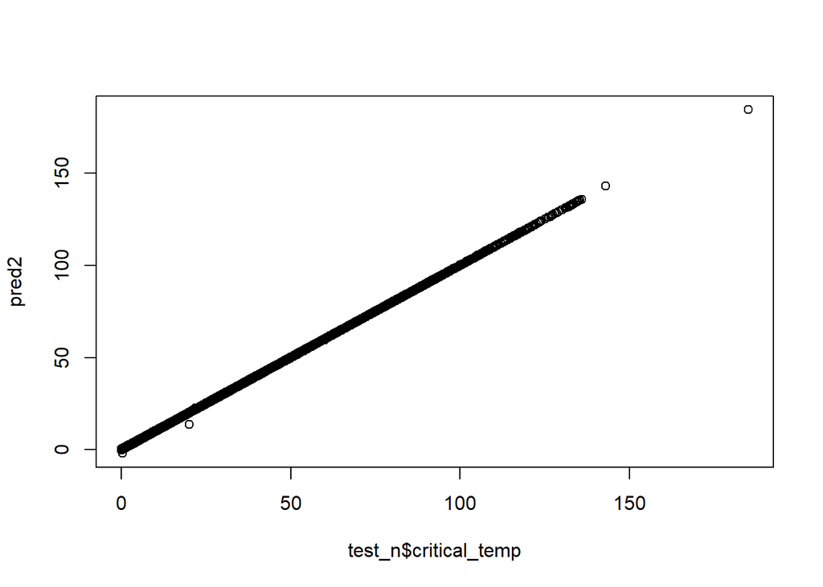

```r
par(mfrow=c(1,1))
plot(test_n$critical_temp, pred2)
```

R-squared is better than previously - that’s either good or bad if I have some mistakes in the code…)

```r
#kpc <- kpca(~.,data=train_n[,-1],kernel="rbfdot", features=5)
# this never ended  :(
```